# PROJECT

# IE 582 FALL 2019 PROJECT

## by Esin AKGÜL & Ramazan YARAR

# FORECASTING SOCCER MATCH RESULTS

## 1 INTRODUCTION

Classification problems are widely used real life applications of machine learning algorithms. The aim of the classification problem is to predict the class of the supplied test data. The prediction is based on the training data and since the model is guided by the class of the training data during the training phase, learning method is called supervised learning. Using classification algorithms to predict sports games’ result is a very common since the historical performance may provide various features for the model. [1]

The aim of this project is to predict results of the matches in the Premier League from 14th round to 21st round. The league consists of 20 clubs and 10 matches are played in each round. The model is developed to provide better predictions than bookmakers for 1x2 bets which describes the result of the match as win of home, tie and win of away. Therefore, the problem is considered as a multiclass classification problem. The model is developed as a multinomial logistic regression since the model is expected to predict three outcomes for a match; win of home, tie and win of away. In order to provide predictions for match results, two data sets are used; bookmakers’ odds and match information. Odds data set consists of 6 different odd types for matches in 2018-2019 season given by 27 bookmakers. For this project, only 1x2 bet type and the latest given odds are used for each match. Matches data set provides information on matches in terms of home and away teams, results of the matches if the match has been played and also the date of the match is provided as epoch time stamp. The data sets are arranged according to needs of the model. In general, odds are matched with match ID’s and transformed into probabilities. For the training data set, the results of the played games are also used. Additionally, with the help of the given data sets some features are obtained to provide forecasts for the results of the matches.

First of all, detailed literature survey is performed to analyze previous applications of machine learning algorithms for predictions of match results. The relevant studies are mentioned in the related literature part. The methodology used in the improvement of the model is explained in the approach section. The outcome of the model will be presented and discussed in the results section. An overview of the results of the project and suggestions for further studies are provided in the conclusions and future work section. Finally, in the code section the git-hub link to the R code of the model is provided.

## 2 RELATED LITERATURE

Several data mining studies are performed for the predictions of soccer match results. The first interesting study is done by Eftim Zdravevski and Andrea Kulakov. They proposed the methodology to develop a model for match result predictions. Their data mining process consists of preprocessing of raw data, selection of features, selection of training and test data. After that, model is trained according to selected data and the outcomes of the test data is predicted. Finally, the results are analyzed according to selected performance measures. The process described by the them is also used in the development of the model in this project. Zdravevski and Kulakov developed several models to predict the classifiers of results of the basketball games. They used 38 different algorithms and compared the precision of the models. According to their results, the logistic regression has the highest precision. [2]

Another significant study with the name Odds-setters as forecasters: The case of English football is published by Forrest et al.. The study compares the performance of the bookmakers and benchmark statistical models incorporated with quantifiable variables. The benchmark model is based on very detailed outputs of previous match results. The study mentions that an ordered probit is used as a benchmark model to provide results-based predictions. They coded the result of the match as 0, 0.5 and 1 for away win, draw and home win, respectively. The training data set consist of 15 preceding seasons of English Premier League. [3]

Goddard and Asimakopoulos also performed a similar study on ordered probit model for predicting football results and examining the efficiency of fixed-odds. [4] The paper investigate the systematic biases in bookmakers’ odds and favorite-longshot bias. Longshot bias is a very significant concept which describes the odds provide biased estimates. The odds are provided in a way which longshots are overbet and favorites are underbet. Therefore, probabilities by the bookmakers can be misleading and the effect of it should be taken into account when working with bookmaker odds. [5]

In order to provide an accurate prediction, the model should be chosen, carefully. Therefore, studies on model comparisons are also significant in the literature. Xiaowei et al. from University of California San Diego performed a comparative study on the models that will give the most accurate predictions on the match results. The data set that they used includes odds of BET365 and BW, results of matches, average goal numbers and average points at the time of the match. Additionally, they also have 22-dimensional player feature and one dimensional rest time feature. The study compares the accuracy of 7 different models; baseline, logistic regression, random forest, Gaussian Naive Bayes, AdaBoost, K-nearest neighbour and support vector machine. Among the accuracy of 7 models, logistic regression has the most satisfying result. The disadvantages of other models, cause predictions to have lower accuracy. They plotted their performances as the following figure. [6]

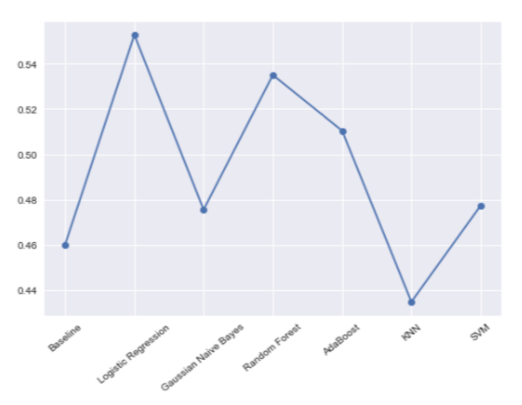

**Figure 1.** Performance comparison of the models. [6]

As seen from the graph, logistic regression is the most successful one to provide more accurate predictions for the match results.

Baboota and Kaur studied the feature selection to increase the accuracy without increasing the dimensionality. The main aim is to eliminate the features that have high correlations. Otherwise, the model would be more likely to stuck in a local minimum. They used ranked probability score (RPS) as the performance matrix and also used confusion matrix to analyze their outcomes. BET 365 and Pinnacle Sports are chosen to compare their model’s prediction performance. [7]

## 3 APPROACH

The aim of the project was to provide forecasts for the match results of matches from 14th to 21st rounds of English Premier League. Therefore 2 data sets are used to extract the features that will be used to train the model. First of all, data sets are preprocessed. Next, according to RPS metric one bookmaker is chosen to work with. Fixture for the seasons are created. Then, features are extracted and evaluated whether they cause correlation which may confuse the model. Then, model is tuned and predictions are obtained.

### 3.2 Match Preprocessing

The data set with the match information has match ID, home and away team names and score of the match in a column. First of all, the number of goals are found for home and away teams and assigned to different columns. Then, the result of the match transformed in to one-hot encode for home win, draw and away win. Then, preprocessed odd and match data are combined.

### 3.4 Bookmaker Selection

The average RPS of the bookmakers for 3 seasons is used for this purpose. The reason why the latest 3 seasons are chosen is to decrease the effect of seasonality. Since, the teams and even the football trends are evolving so quickly, working on 3 seasons would increase the misleading effect of it. Also, the number of the supplied odds from a bookmaker is taken into account when choosing the bookmaker to work with. As a result, the odds of Pinnacle Sports are chosen to work with. Additionally, it is known that the bookmakers supply multiple odds before the games. In order to decrease possible misleading of the previous odds, the final odd before each game is used to obtain the probability.

### 3.5 Feature Extraction

In order to obtain the features to build the model, a fixture is created. This fixture contains 2 rows for each match; one for home team and one for away team. In this fixture, the point earned from the match, total cumulative point of the team, week of the match are summarized. The status which identifies if the team is home or away team is also present in this fixture. Then, feature extraction is applied. In total, 24 features are extracted and analyzed with respect to their importance. The importance measurement will be explained in the next section. First of all, the total point for the home and away teams are used. For total grade calculation, 1 point is given to the winning team, 0.5 is given to both teams if the match is draw and 0 point is given to the losing team. This system is widely used in literature to study the results prediction of soccer games. [4] The total points at the week of the match represent the number of winnings and draws in the previous weeks, in general. This can be considered as a general measure of the team performance until the match. Secondly, rps metric of each team is calculated for 4 different conditions; rps in the last 5 matches when the team was the away, rps in the last 5 matches when the team was the home, rps of the home team when it was home in the previous games and , rps of the away team when it was away in the previous games. This feature stands for the previous performance of the bookmakers. Therefore, adding it as a feature takes the variance of the match results and possible surprise win by a team. In addition, there is also a feature which represents the significant differences in the odds from the average of previous odds. This features is developed by analyzing the previous odds for each team. Then, the median of the odds given for the team when away and home are found, separately. If the odd for the particular match is significantly different than before, the is.special feature categorically identifies the case. Additionally, there are also some other features extracted which did not perform well on the significance test. Those features are based on the performance of the teams in the last 3 games. They are such as number of goals by the home team, defeat count of the home team and away team, and win ratio in the home or away and so on. Additionally, in some cases, some features performed satisfactory but the variance of the results were so large. Since, the objective of the forecasting is achieving the best performance in a round, features with large variance are also eliminated.

### 3.6 Feature Importance

Since, the odds supplied by the bookmakers are used as the reference data, new features should be added carefully. Variables used by the bookmakers are now publicly available. Therefore, adding features that are already in the odds would make the model to overfit and perform poorly. Therefore, correlation matrix of the features are created. As a result, 10 features are used to train the model.

## 4 RESULTS

For the evaluation of the bookmakers, rps performance for the previous seasons are analyzed. The summary table for the last 3 years are given in the table below.

**Table 1.** Bookmaker RPS Performances for 3 Seasons

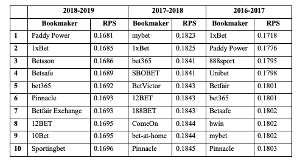

Number of predictions by each bookmaker is also analyzed. Top ten bookmakers has the same number of predictions. As seen from the table, the bottom ones have less number opredictions. Therefore, even though they have small rps values, their reliability is not strong. Pinnacle is present in top 10 in the RPS performance table for 3 years. Its standing in the middle is interprets that it represent the median of all bookmakers.

**Table 2.** Number of Predicted Matches in 3 seasons from 2018-2019 to 2016-2017

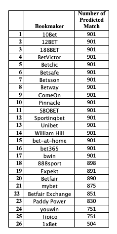

During 8 round project, different features are tried for the model. Since the variance in the intermediate weeks is high, some of the submitted probabilities did not perform as expected. During the 8 round period the new features are created. For instance, in the first week, the model had only 5 features. In the following weeks feature number increased. Finally, correlation matrix is constructed and the final features are obtained.

**Table 3 .** Correlation Matrix for the Features

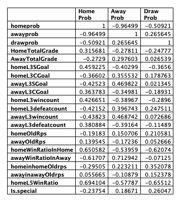

With the help of the table above, the correlated features are eliminated.

Additionally, the accuracy in a round may differ significantly due continuous supply of odds. The submissions of the project are done 1 hour before the first match of the round. However, rounds usually last for 2-3 days . In 2 days, bookmakers continue to change their odds. Therefore, the probabilities obtained by the model may deviate in a round.

Random forest is also tried in this data set. However, since our performance metric is RPS, the model did not perform well. Therefore, any further work with random forest is not performed.

Finally, the model is run for the matches in the previous weeks to see the performance. The results table is as below;

**Table 4 .** Final Model Performance in the Previous Rounds

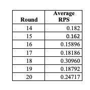

## 5 CONCLUSIONS AND FUTURE WORK

The project aims to provide accurate forecasts for Premier League for the matches from 14th round to 21st round. For this purpose, two data sets which consist of match information and odds supplied by the bookmakers are processed. The prediction problem in this case is a supervised multinomial classification. In order to solve the problem, detailed literature research is performed. Then, with processing the data sets, variables of the model are obtained and model is developed. When extracting the features of the model, several references and also business insights are used. As a result, total number of extracted features is 24 but only 10 features passed the significance test and had relatively low variances for the rounds. Therefore, finally those 10 features are used to predict the matches. In order to increase the accuracy of the predictions, different models are searched. However, as the literature states, multinomial logistic regression is the most successful model to provide accurate predictions for the match results. Therefore, multinomial logistic regression is used. The RPS metric is used to measure the performance of the model. With the model developed, an average RPS of 0.204 is obtained for 7 rounds of submission. When the best 6 rounds are taken into account the average RPS even drops to 0.187

For further studies, the odds fluctuations of a match can be observed in detail. Next, new features can be extracted with the information extracted from the fluctuations. When, the odds are analyzed in detail, for some matches bookmakers start to publish odds even 3 months before the game. Therefore, working with the temporal movement of the odds may provide information for accurate forecasts. Additionally, defining a variable which describes the performance of the bookmakers for matches with different difficulties may improve the bookmaker selection procedure. With the help of this, instead of using single bookmaker, different bookmaker with optimized performances can be used.

## 6 CODE

Code link can be found in the progress journal.

## REFERENCES

[1] Bunker, Rory P., and Fadi Thabtah. “A Machine Learning Framework for Sport Result Prediction.” Applied Computing and Informatics, 2017, doi:10.1016/j.aci.2017.09.005.

[2] Zdravevski, Eftim, and Andrea Kulakov. “System for Prediction of the Winner in a Sports Game.” ICT Innovations 2009, 2010, pp. 55–63., doi:10.1007/978-3-642-10781-8_7.

[3] Forrest, David, et al. “Odds-Setters as Forecasters: The Case of English Football.” International Journal of Forecasting, vol. 21, no. 3, 2005, pp. 551–564., doi:10.1016/j.ijforecast.2005.03.003.

[4] Goddard, John, and Ioannis Asimakopoulos. “Forecasting Football Results and the Efficiency of Fixed-Odds Betting.” Journal of Forecasting, vol. 23, no. 1, 2004, pp. 51–66., doi:10.1002/for.877.

[5] Snowberg, Erik, and Justin Wolfers. “Explaining the Favorite-Longshot Bias: Is It Risk-Love or Misperceptions?” 2010, doi:10.3386/w15923.

[6] Xiaowei, Liang, et al. “Result Prediction for European Football Games.”

[7] Baboota, Rahul, and Harleen Kaur. “Predictive Analysis and Modelling Football Results Using Machine Learning Approach for English Premier League.” International Journal of Forecasting, 2018, doi:10.1016/j.ijforecast.2018.01.003.